# Data Cleaning Course Project

MCCurcio

1/14/2021

# 1 Data Cleaning Course Project

**Introduction**

The [Human Activity Recognition Using Smartphones Dataset, Version 1.0](https://archive.ics.uci.edu/ml/datasets/Human+Activity+Recognition+Using+Smartphones) is provided in eight(8) files. Six(7) of these files will be bound together to provide one dataframe.

[output not shown]

The best way for me to explain the data organization (even to myself) is to use a diagram.

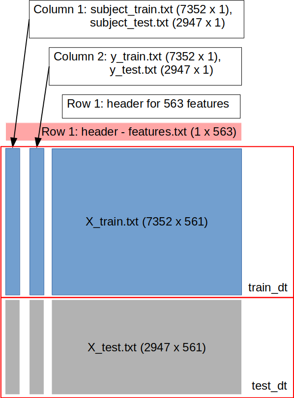

Exploded Diagram of Dataframe

## 1.1 Questions & Initial Data Analysis

### 1.1.1 Load `smartphone_dt` data tables

```r
getwd()
```

```
## [1] "/home/mcc/Dropbox/R_exercises/Coursera_Materials/Data_cleaning/course_project"
```

```r
# Load libraries
my_packages <- c("dplyr", "data.table")
lapply(my_packages, library, character.only = TRUE)
```

```
## [[1]]
## [1] "dplyr"     "stats"     "grDevices" "utils"     "datasets"  "graphics"
## [7] "methods"   "base"
##
## [[2]]
## [1] "data.table" "dplyr"      "stats"      "grDevices"  "utils"
## [6] "datasets"   "graphics"   "methods"    "base"
```

**List `smartphone_dt` data tables**

```r
files <- list.files(pattern = "*.txt")
smartphone_dt <- lapply(files, fread)

class(smartphone_dt)
```

```
## [1] "list"
```

```r
files
```

```
## [1] "activity_labels.txt" "features.txt"        "subject_test.txt"
## [4] "subject_train.txt"   "X_test.txt"          "X_train.txt"
## [7] "y_test.txt"          "y_train.txt"
```

- Q. Determine for unique numbers in *subject_test.txt* and *subject_train.txt*.

### 1.1.2 `subject_train.txt` contains 21 subjects

- 21 subjects were found
- `subject_train.txt` contains {1,3,5,6,7,8,11,14,15,16,17,19,21,22,23,25,26,27,28,29,30}

```r
subject_train <- smartphone_dt[[4]]

unique_train <- as.list(unique(subject_train))
unique_train
```

```
## $V1
##  [1]  1  3  5  6  7  8 11 14 15 16 17 19 21 22 23 25 26 27 28 29 30
```

```r
length_train <- lengths(unique_train)
length_train
```

```
## V1
## 21
```

```r
#dim(subject_train)
```

### 1.1.3 `subject_test.txt` contains 9 subjects

- 9 subjects were found
- `subject_test.txt` contains {2,4,9,10,12,13,18,20,24}

```r
subject_test <- smartphone_dt[[3]]

unique_test <- as.list(unique(subject_test))
unique_test
```

```
## $V1
## [1]  2  4  9 10 12 13 18 20 24
```

```r
length_test <- lengths(unique_test)
length_test
```

```
## V1
##  9
```

```r
#dim(subject_test)
```

### 1.1.4 `activity_labels.txt` contains 6 labels

- [1, WALKING],
- [2, WALKING_UPSTAIRS],
- [3, WALKING_DOWNSTAIRS],
- [4, SITTING],
- [5, STANDING],
- [6, LAYING]

```r
activities <- smartphone_dt[[1]]

unique_activities <- as.list(unique(activities))
unique_activities
```

```
## $V1
## [1] 1 2 3 4 5 6
##
## $V2
## [1] "WALKING"            "WALKING_UPSTAIRS"   "WALKING_DOWNSTAIRS"
## [4] "SITTING"            "STANDING"           "LAYING"
```

```r
#dim(activities)
```

### 1.1.5 Merge Seven (7) datasets

[1] “activity_labels.txt” “features.txt” “subject_test.txt” “subject_train.txt”  
[5] “X_test.txt” “X_train.txt” “y_test.txt” “y_train.txt”

```r
train_dt <- cbind(smartphone_dt[[4]], smartphone_dt[[8]], smartphone_dt[[6]])
test_dt  <- cbind(smartphone_dt[[3]], smartphone_dt[[7]], smartphone_dt[[5]])

t_t_dt <- rbind(train_dt, test_dt)
```

- Step 4: Merge “subject_num”, “y_labels” & features.txt to produce `all_col_names`.
- Step 5: Assign column names, `all_col_names` to t_t_dt, (train-test data tables)

```r
all_col_names <- c("SubjectNumber", "YLabels", smartphone_dt[[2]][[2]])

colnames(t_t_dt) <- all_col_names

t_t_dt[1:3, 1:5]
```

```
##    SubjectNumber YLabels tBodyAcc-mean-X tBodyAcc-mean-Y tBodyAcc-mean-Z
## 1:             1       5       0.2885845     -0.02029417      -0.1329051
## 2:             1       5       0.2784188     -0.01641057      -0.1235202
## 3:             1       5       0.2796531     -0.01946716      -0.1134617
```

```r
write.table(t_t_dt, file = "merged_dataset.csv", row.names = FALSE)
```

- Step 6: Create `Tidy_Data_Set.txt` with the average of each variable for each activity(YLabels) and each Subject Number(SubjectNumber).

```r
##Part 5 - From the data set in step 4, creates a second, independent tidy data set with the average of each variable for each activity and each subject

t_t_dt$SubjectNumber <- as.factor(t_t_dt$SubjectNumber)
t_t_dt <- data.table(t_t_dt)

mean_values <- aggregate(. ~ SubjectNumber + YLabels, t_t_dt, mean)
mean_values <- mean_values[order(mean_values$SubjectNumber, mean_values$YLabels), ]
write.table(mean_values, file = "mean_values.csv", row.names = FALSE)
```

## 1.2 Appendix

### 1.2.1 Assignment

You are required to submit:

1. a tidy data set
2. The GitHub repository with the course project is at: https://github.com/mccurcio/data_cleaning_project
3. Generate `CodeBook.md` that describes **variables, data, any transformations or work** that you performed to clean up the data.
4. Generate `README.md`
5. This repo explains how all of the scripts work and how they are connected.
   - Produce list of steps used to re-create data.

### 1.2.2 Review criteria:

The submitted material will be reviewed on 5 criteria:

1. Your submitted data set is tidy.
2. Your Github repo contains the required scripts.
3. GitHub contains a code book that modifies and updates the available codebooks with the data to indicate all the variables and summaries calculated, along with units, and any other relevant information.
4. A README that explains the analysis files is clear and understandable.
5. The work submitted for this project is the work of the student who submitted it.

### 1.2.3 Getting and Cleaning Data Course Project

The purpose of this project is to demonstrate your ability to collect, work with, and clean a data set. The goal is to prepare tidy data that can be used for later analysis. You will be graded by your peers on a series of yes/no questions related to the project. **Here are the data for the project:**

- https://d396qusza40orc.cloudfront.net/getdata%2Fprojectfiles%2FUCI%20HAR%20Dataset.zip
1. Create `run_analysis.R`
2. Create `merged_dataset.csv`, merging the training and test sets.
3. Extracts only the **measurements on the mean and standard deviation** for each measurement.
   - Create table of feature means and stdevs
4. Uses **descriptive activity names** to name the activities in the data set.
5. Appropriately **labels the data set with descriptive variable names.**
6. From the data set in step 4, creates a second, independent tidy data set with the average of each variable for each activity and each subject.
   - Create tidy dataset for activity (1-6)
   - Create tidy dataset for each subject (#?)

EOF